# Customer Segregation in R

Olusanya Joshua

2025-09-10

# Introduction

In this notebook, I performed customer segmentation using the Mall Customers dataset obtained from kaggle data repository.  
I used the **K-Means clustering** to group customers based on their **Annual Income** and **Spending Score**.

# Step 1: Load Libraries

```r
library(tidyverse)
library(cluster)
library(factoextra)
knitr::opts_chunk$set(echo = TRUE)
```

# Step 2 : Loading the dataset

```r
data <- read.csv("C:/Users/asus/OneDrive/Desktop/my portfolio projects/Mall_Customers.csv")
head(data)
```

```
##   CustomerID Gender Age Annual.Income..k.. Spending.Score..1.100.
## 1          1   Male  19                 15                     39
## 2          2   Male  21                 15                     81
## 3          3 Female  20                 16                      6
## 4          4 Female  23                 16                     77
## 5          5 Female  31                 17                     40
## 6          6 Female  22                 17                     76
```

# Step 3 : Feature Selection

```r
df <- data %>% select(Annual.Income..k..,Spending.Score..1.100.)
knitr::opts_chunk$set(echo = TRUE)
```

# Step 4 : Scaling the data and using the Elbow method

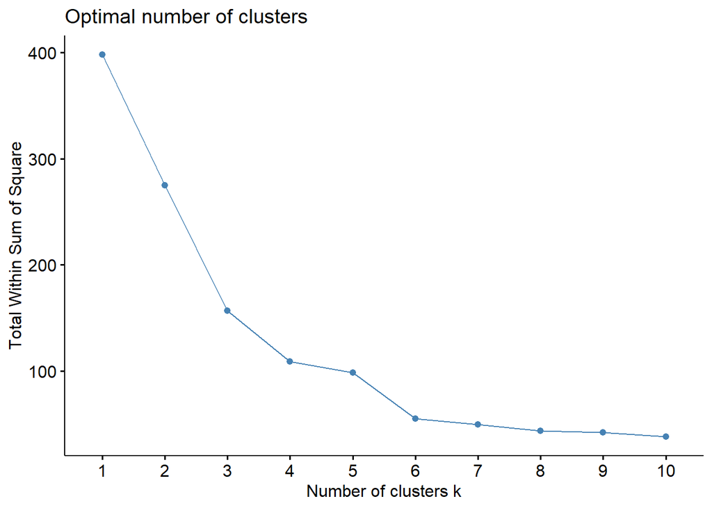

```r
df_scaled = scale(df)
fviz_nbclust(df_scaled, kmeans, method ='wss') # elbow method
```

```r
knitr::opts_chunk$set(echo = TRUE)
```

# Step 5 : clustering

```r
set.seed(123)
km <- kmeans(df_scaled, center = 5, nstart=25)
km
```

```
## K-means clustering with 5 clusters of sizes 81, 23, 22, 35, 39
##
## Cluster means:
##   Annual.Income..k.. Spending.Score..1.100.
## 1         -0.2004097            -0.02638995
## 2         -1.3042458            -1.13411939
## 3         -1.3262173             1.12934389
## 4          1.0523622            -1.28122394
## 5          0.9891010             1.23640011
##
## Clustering vector:
##   [1] 2 3 2 3 2 3 2 3 2 3 2 3 2 3 2 3 2 3 2 3 2 3 2 3 2 3 2 3 2 3 2 3 2 3 2 3 2
##  [38] 3 2 3 2 3 2 1 2 3 1 1 1 1 1 1 1 1 1 1 1 1 1 1 1 1 1 1 1 1 1 1 1 1 1 1 1 1
##  [75] 1 1 1 1 1 1 1 1 1 1 1 1 1 1 1 1 1 1 1 1 1 1 1 1 1 1 1 1 1 1 1 1 1 1 1 1 1
## [112] 1 1 1 1 1 1 1 1 1 1 1 1 5 4 5 1 5 4 5 4 5 1 5 4 5 4 5 4 5 4 5 1 5 4 5 4 5
## [149] 4 5 4 5 4 5 4 5 4 5 4 5 4 5 4 5 4 5 4 5 4 5 4 5 4 5 4 5 4 5 4 5 4 5 4 5 4
## [186] 5 4 5 4 5 4 5 4 5 4 5 4 5 4 5
##
## Within cluster sum of squares by cluster:
## [1] 14.485632  7.577407  5.217630 18.304646 19.655252
##  (between_SS / total_SS =  83.6 %)
##
## Available components:
##
## [1] "cluster"      "centers"      "totss"        "withinss"     "tot.withinss"
## [6] "betweenss"    "size"         "iter"         "ifault"
```

```r
df_clustered <- data %>% mutate(Cluster= factor(km$cluster))
df_clustered # to view clustered table
```

```
##     CustomerID Gender Age Annual.Income..k.. Spending.Score..1.100. Cluster
## 1            1   Male  19                 15                     39       2
## 2            2   Male  21                 15                     81       3
## 3            3 Female  20                 16                      6       2
## 4            4 Female  23                 16                     77       3
## 5            5 Female  31                 17                     40       2
## 6            6 Female  22                 17                     76       3
## 7            7 Female  35                 18                      6       2
## 8            8 Female  23                 18                     94       3
## 9            9   Male  64                 19                      3       2
## 10          10 Female  30                 19                     72       3
## 11          11   Male  67                 19                     14       2
## 12          12 Female  35                 19                     99       3
## 13          13 Female  58                 20                     15       2
## 14          14 Female  24                 20                     77       3
```

[output cut: 186 more lines]

```r
knitr::opts_chunk$set(echo = TRUE)
```

# Step 6 : Visualization

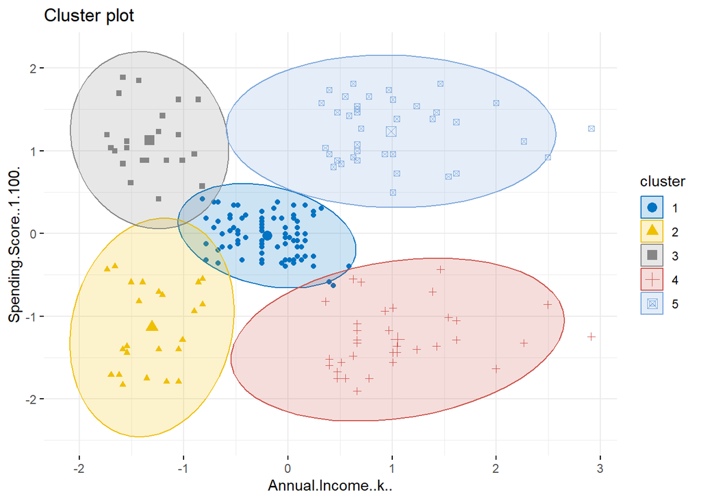

```r
fviz_cluster(km, df_scaled,
             ellipse.type = 'norm',
             geom ='point',
             palette ='jco',
             ggtheme =theme_minimal())
```

```r
library(ggplot2)

# Calculate summary stats per cluster
cluster_summary <- df_clustered %>%
  group_by(Cluster) %>%
  summarise(
    Avg_Income = mean(Annual.Income..k..),
    Avg_Spending = mean(Spending.Score..1.100.),
    Count = n()
  )
```

# Bar plot: Average Income per Cluster

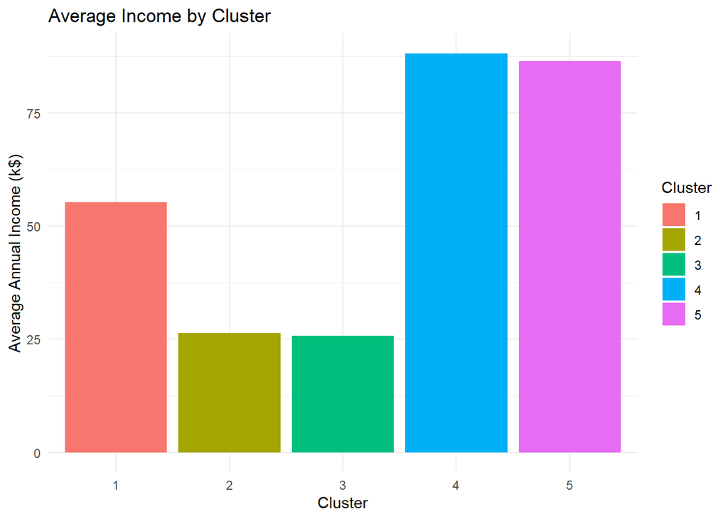

```r
ggplot(cluster_summary, aes(x = Cluster, y = Avg_Income, fill = Cluster)) +
  geom_col() +
  theme_minimal() +
  labs(title = "Average Income by Cluster",
       x = "Cluster",
       y = "Average Annual Income (k$)")
```

# Bar plot: Average Spending per Cluster

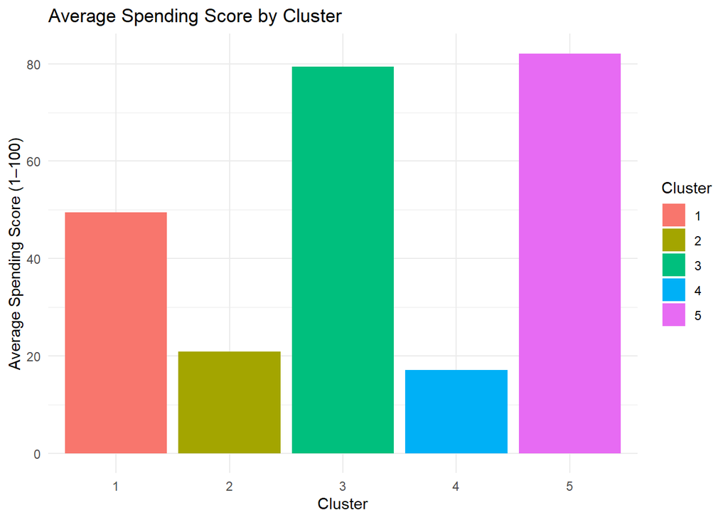

```r
ggplot(cluster_summary, aes(x = Cluster, y = Avg_Spending, fill = Cluster)) +
  geom_col() +
  theme_minimal() +
  labs(title = "Average Spending Score by Cluster",
       x = "Cluster",
       y = "Average Spending Score (1–100)")
```

# Summary

X-axis (Annual Income..k..) → left = low income, right = high income

Y-axis (Spending Score..1.100.) → bottom = low spending, top = high spending

Each color/shape = one cluster, ellipse shows its spread

**Cluster 1 (dark blue dots, middle-left)**

Middle income, middle spending Balanced customers, average behavior Strategy: maintain engagement

**Cluster 2 (yellow triangles, bottom-left)**

Low income, low spending Budget-conscious customers, low profitability Strategy: offer discounts, low-cost promotions

**Cluster 3 (gray squares, top-left)**

Low income, high spending Value seekers / impulsive spenders Strategy: promote affordable luxury, seasonal offers

**Cluster 4 (red crosses, bottom-right)**

High income, low spending Wealthy but cautious customers Strategy: targeted premium campaigns, loyalty programs

**Cluster 5 (light blue squares with border, top-right)**

High income, high spending Premium/VIP customers Strategy: exclusive offers, VIP programs, retain at all costs